# ecommerce_data_analysis

#### **Customer segmentation on interactions and purchasing behaviors on the different platforms**

```python
from sklearn.preprocessing import StandardScaler
from sklearn.preprocessing import OneHotEncoder
from sklearn.cluster import KMeans
import scipy.cluster.hierarchy as shc
from matplotlib import pyplot
from sklearn.metrics import silhouette_score
from sklearn.mixture import GaussianMixture
```

```python
# Load datasets
sales_df = pd.read_csv("./data/sales.csv")
cars_df = pd.read_csv("./data/cars.csv")
visits_df = pd.read_csv("./data/visits.csv")
```

```python
df = sales_df.merge(cars_df, on="car_id", how="left")
df.head()
```

|  | transaction_id | customer_id | car_id | platform | purchase_date | purchase_price | user_review | car_model | fuel_type | release_date | price |
| --- | --- | --- | --- | --- | --- | --- | --- | --- | --- | --- | --- |
| 0 | d8ea7895-4dda-4419-9291-5fe446c8d387 | d4a436e4-938c-4281-9c9c-5912be025b19 | 5fae80e1-82d6-45d3-8512-7db7bb32d5bd | Website | 2021-10-14 | 45000.0 | NaN | Sedan | Gasoline | 2018-07-15 | 45000 |
| 1 | 73bba083-92ea-4580-80ef-527193c8a897 | 1105c980-82a0-4296-8de0-fcb37fbdd435 | eee54c45-64fe-462b-b9c2-e23adea76282 | Dealership | 2022-11-03 | 30000.0 | NaN | 1 Series | Diesel | 2010-10-01 | 30000 |
| 2 | 4150e505-a55e-4eb8-b321-92ed2e96553e | 8c987376-6996-4137-977a-5415b81b55d0 | ab72e1ef-639f-4ad0-b9b0-28a50f3c7229 | Website | 2023-12-14 | 131000.0 | NaN | Model iX | Electric | 2017-11-10 | 131000 |
| 3 | 5bf1dbeb-6469-4b77-accd-4af5ce6a48a2 | 9289286a-dece-4d9c-9d64-fafd949f7fb0 | 0c048ea4-5e29-419e-a448-99f75742117c | Dealership | 2023-02-14 | 70000.0 | NaN | Model M | Gasoline | 2016-04-01 | 70000 |
| 4 | e7e61ff9-0ac3-4101-b195-369faa256f79 | ba30d504-d66f-4879-8af3-999884f2e0f8 | eee54c45-64fe-462b-b9c2-e23adea76282 | Dealership | 2022-07-04 | 30000.0 | 1.0 | 1 Series | Diesel | 2010-10-01 | 30000 |

##### **Feature Engineering**

- We will be performing customer segmentation based on interactions and purchasing behaviors across various platforms. The visis_df dataset includes different types of user visits, providing necessary insights for this task.
- Therefore, it is important to present these interactions in a format that can be utilized by clustering algorithms in subsequent steps."

```python
# On customer, count different types of visits
pivot_visit_df = visits_df.pivot_table(index='customer_id', columns='visit_type', aggfunc='size', fill_value=0)
pivot_visit_df.reset_index(inplace=True)
pivot_visit_df
```

| visit_type | customer_id | car configuration | purchasing | testing | viewing |
| --- | --- | --- | --- | --- | --- |
| 0 | 00002fb6-1bad-48bf-ba4f-343fe4a2b31d | 1 | 0 | 0 | 1 |
| 1 | 00018dda-2d4b-4abb-8629-98a9063a5cba | 0 | 1 | 0 | 2 |
| 2 | 0001efdb-9ec2-4a1e-afed-88c7dee53e15 | 0 | 1 | 1 | 2 |
| 3 | 00025afa-8bb4-41da-808b-4d31a09d8768 | 0 | 1 | 0 | 3 |
| 4 | 00028dd5-4065-4234-9dad-b8bbc0a93c76 | 1 | 0 | 0 | 0 |
| ... | ... | ... | ... | ... | ... |
| 136171 | ffff65e7-6f08-4433-9592-91cceae8e0f3 | 1 | 0 | 0 | 0 |
| 136172 | ffff65f1-e7ed-4f14-91b3-3a008886e5ae | 0 | 1 | 0 | 2 |
| 136173 | ffffb6ab-5d71-4ba3-81e7-93fb2b8243dd | 0 | 0 | 0 | 1 |
| 136174 | ffffc673-0b2c-4536-9218-f326ce03e513 | 1 | 1 | 0 | 0 |
| 136175 | ffffe1b3-a481-44d5-b48c-a3d4d30e245c | 1 | 1 | 3 | 1 |

136176 rows × 5 columns

```python
# Merge with the original visit_df
visits_df = visits_df.merge(pivot_visit_df, on="customer_id", how="left")
visits_df.head()
```

|  | visit_id | customer_id | start_timestamp | end_timestamp | visit_type | transaction_id | car configuration | purchasing | testing | viewing |
| --- | --- | --- | --- | --- | --- | --- | --- | --- | --- | --- |
| 0 | 7f94232d-9cca-4893-aebe-9a267a752f87 | de5323eb-5e01-481f-b73a-bb78af953894 | 2023-04-18 10:51:24.477465 | 2023-04-18 11:46:26.893492 | car configuration | NaN | 1 | 0 | 1 | 0 |
| 1 | dcb32330-15b0-4fd1-b376-9b9335fee7f9 | 15dcef30-b549-447b-8809-229c9de8526b | 2021-03-03 17:54:25.117599 | 2021-03-03 18:07:25.117599 | viewing | NaN | 0 | 1 | 0 | 3 |
| 2 | 8b02d675-1365-45bc-af64-61ef9e79149c | 3b656455-1690-47d9-b7ad-9e0aaa3bb229 | 2023-07-07 13:09:00.000000 | 2023-07-07 13:19:00.000000 | purchasing | d1bfe5f5-edc1-4148-8eb0-8127dd3b52c1 | 0 | 1 | 1 | 2 |
| 3 | bdfc7048-adc5-4da7-a37a-4f9d90cf6436 | c583c671-2f8a-47f3-9460-bd444b1811c8 | 2023-09-14 11:25:12.820271 | 2023-09-14 12:20:15.523626 | car configuration | NaN | 1 | 0 | 0 | 0 |
| 4 | 2ad3a1e1-0b9c-417f-95f7-70607b0fe96e | da8268d8-4e81-4538-bf1d-836ac4d5b155 | 2020-12-04 19:15:41.833927 | 2020-12-04 19:27:41.833927 | car configuration | NaN | 3 | 1 | 0 | 2 |

```python
# Merged with main dataset
df = df.merge(visits_df, on=["customer_id", "transaction_id"], how="left")
df.head()
```

|  | transaction_id | customer_id | car_id | platform | purchase_date | purchase_price | user_review | car_model | fuel_type | release_date | price | visit_id | start_timestamp | end_timestamp | visit_type | car configuration | purchasing | testing | viewing |
| --- | --- | --- | --- | --- | --- | --- | --- | --- | --- | --- | --- | --- | --- | --- | --- | --- | --- | --- | --- |
| 0 | d8ea7895-4dda-4419-9291-5fe446c8d387 | d4a436e4-938c-4281-9c9c-5912be025b19 | 5fae80e1-82d6-45d3-8512-7db7bb32d5bd | Website | 2021-10-14 | 45000.0 | NaN | Sedan | Gasoline | 2018-07-15 | 45000 | abeb229e-fbcf-4c1f-91ce-45cc21f638b2 | 2021-10-14 12:29:00.000000 | 2021-10-14 12:41:00.000000 | purchasing | 0.0 | 1.0 | 0.0 | 4.0 |
| 1 | 73bba083-92ea-4580-80ef-527193c8a897 | 1105c980-82a0-4296-8de0-fcb37fbdd435 | eee54c45-64fe-462b-b9c2-e23adea76282 | Dealership | 2022-11-03 | 30000.0 | NaN | 1 Series | Diesel | 2010-10-01 | 30000 | c1d10ab9-cf09-424d-9b2f-a09f885d5cd1 | 2022-11-03 14:26:00.000000 | 2022-11-03 14:31:00.000000 | purchasing | 1.0 | 1.0 | 2.0 | 1.0 |
| 2 | 4150e505-a55e-4eb8-b321-92ed2e96553e | 8c987376-6996-4137-977a-5415b81b55d0 | ab72e1ef-639f-4ad0-b9b0-28a50f3c7229 | Website | 2023-12-14 | 131000.0 | NaN | Model iX | Electric | 2017-11-10 | 131000 | 9453e659-b577-4aad-9c93-5c13cf643764 | 2023-12-14 12:57:00.000000 | 2023-12-14 13:09:00.000000 | purchasing | 0.0 | 1.0 | 0.0 | 5.0 |
| 3 | 5bf1dbeb-6469-4b77-accd-4af5ce6a48a2 | 9289286a-dece-4d9c-9d64-fafd949f7fb0 | 0c048ea4-5e29-419e-a448-99f75742117c | Dealership | 2023-02-14 | 70000.0 | NaN | Model M | Gasoline | 2016-04-01 | 70000 | b8a25c77-e999-4c28-b155-c1a672466e67 | 2023-02-14 14:42:00.000000 | 2023-02-14 14:50:00.000000 | purchasing | 1.0 | 1.0 | 1.0 | 5.0 |
| 4 | e7e61ff9-0ac3-4101-b195-369faa256f79 | ba30d504-d66f-4879-8af3-999884f2e0f8 | eee54c45-64fe-462b-b9c2-e23adea76282 | Dealership | 2022-07-04 | 30000.0 | 1.0 | 1 Series | Diesel | 2010-10-01 | 30000 | 121d7e4f-d089-445f-bae0-7cfd03e56c1e | 2022-07-04 16:15:00.000000 | 2022-07-04 16:24:00.000000 | purchasing | 0.0 | 1.0 | 3.0 | 3.0 |

```python
df.columns
```

```
Index(['transaction_id', 'customer_id', 'car_id', 'platform', 'purchase_date',
       'purchase_price', 'user_review', 'car_model', 'fuel_type',
       'release_date', 'price', 'visit_id', 'start_timestamp', 'end_timestamp',
       'visit_type', 'car configuration', 'purchasing', 'testing', 'viewing'],
      dtype='object')
```

##### **Feature Selection**

- The current dataframe (df) contains 19 features. We need to eliminate unnecessary information for this task because extraneous features may incomplete the model and lead to poor performance."

```python
columns_to_drop = ["transaction_id", "customer_id", "car_id", "purchase_date",
                   "user_review", "car_model","release_date", "price",
                   "visit_id", "start_timestamp", "end_timestamp", "visit_type",
                   "purchase_price","fuel_type"]

df.drop(columns=columns_to_drop, inplace=True)
df.head()
```

|  | platform | car configuration | purchasing | testing | viewing |
| --- | --- | --- | --- | --- | --- |
| 0 | Website | 0.0 | 1.0 | 0.0 | 4.0 |
| 1 | Dealership | 1.0 | 1.0 | 2.0 | 1.0 |
| 2 | Website | 0.0 | 1.0 | 0.0 | 5.0 |
| 3 | Dealership | 1.0 | 1.0 | 1.0 | 5.0 |
| 4 | Dealership | 0.0 | 1.0 | 3.0 | 3.0 |

##### **Data Prepration**

```python
# Check for null values
df.isna().sum()
```

```
platform              0
car configuration    56
purchasing           56
testing              56
viewing              56
dtype: int64
```

```python
# Fill Nan with 0
df = df.fillna(0)
```

```python
# Normalize numerical features
scaler = StandardScaler()

numerical_columns = ["car configuration", "purchasing",
                     "testing", "viewing"]

df[numerical_columns] = scaler.fit_transform(df[numerical_columns])
df.head()
```

|  | platform | car configuration | purchasing | testing | viewing |
| --- | --- | --- | --- | --- | --- |
| 0 | Website | -0.665217 | 0.01034 | -0.574067 | 1.278780 |
| 1 | Dealership | 0.513897 | 0.01034 | 1.687688 | -0.754192 |
| 2 | Website | -0.665217 | 0.01034 | -0.574067 | 1.956437 |
| 3 | Dealership | 0.513897 | 0.01034 | 0.556810 | 1.956437 |
| 4 | Dealership | -0.665217 | 0.01034 | 2.818565 | 0.601123 |

```python
# Encode numerical features
encoder = OneHotEncoder()

categorical_columns = ['platform']

encoded_data = encoder.fit_transform(df[categorical_columns])
encoded_columns = encoder.get_feature_names_out(categorical_columns)
encoded_df = pd.DataFrame(encoded_data.toarray(), columns=encoded_columns)

df = pd.concat([df, encoded_df], axis=1)
df.drop(columns=categorical_columns, inplace=True)
df.head()
```

|  | car configuration | purchasing | testing | viewing | platform_Dealership | platform_Mobile App | platform_Website |
| --- | --- | --- | --- | --- | --- | --- | --- |
| 0 | -0.665217 | 0.01034 | -0.574067 | 1.278780 | 0.0 | 0.0 | 1.0 |
| 1 | 0.513897 | 0.01034 | 1.687688 | -0.754192 | 1.0 | 0.0 | 0.0 |
| 2 | -0.665217 | 0.01034 | -0.574067 | 1.956437 | 0.0 | 0.0 | 1.0 |
| 3 | 0.513897 | 0.01034 | 0.556810 | 1.956437 | 1.0 | 0.0 | 0.0 |
| 4 | -0.665217 | 0.01034 | 2.818565 | 0.601123 | 1.0 | 0.0 | 0.0 |

```python
df.shape
```

```
(74836, 7)
```

##### **K-Means**

- The Elbow Method will be utilized to find the optimal number of clusters.

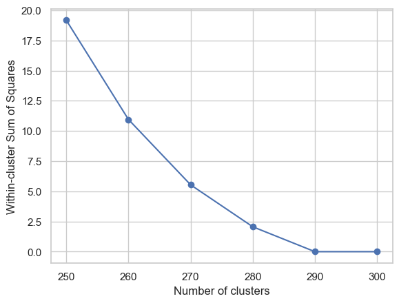

```python
# Optimizing respect to Within-cluster Sum of Squares
inertias = []
range_ = range(250, 301, 10)

for k in range_:
    kmeans = KMeans(n_clusters=k)
    kmeans.fit(df)
    inertias.append(kmeans.inertia_)

# Plot
plt.plot(range_, inertias, marker='o')
plt.xlabel('Number of clusters')
plt.ylabel('Within-cluster Sum of Squares')
plt.show()
```

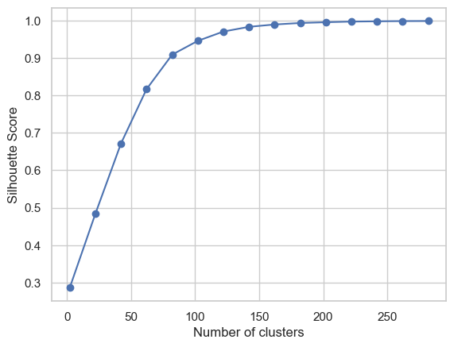

```python
# Optimizing respect to Silhouette Score
silhouette_scores = []
range_ = range(2, 302, 20)

for k in range_:
    kmeans = KMeans(n_clusters=k)
    kmeans.fit(df)
    score = silhouette_score(df, kmeans.labels_)
    silhouette_scores.append(score)

plt.plot(range_, silhouette_scores, marker='o')
plt.xlabel('Number of clusters')
plt.ylabel('Silhouette Score')
plt.show()
```

##### **Dendrograms**

- Since the number of points is huge and given my computational limits, I will sample a subset of the dataset and investigate accordingly. In a full analysis, one can comment on sample_df.

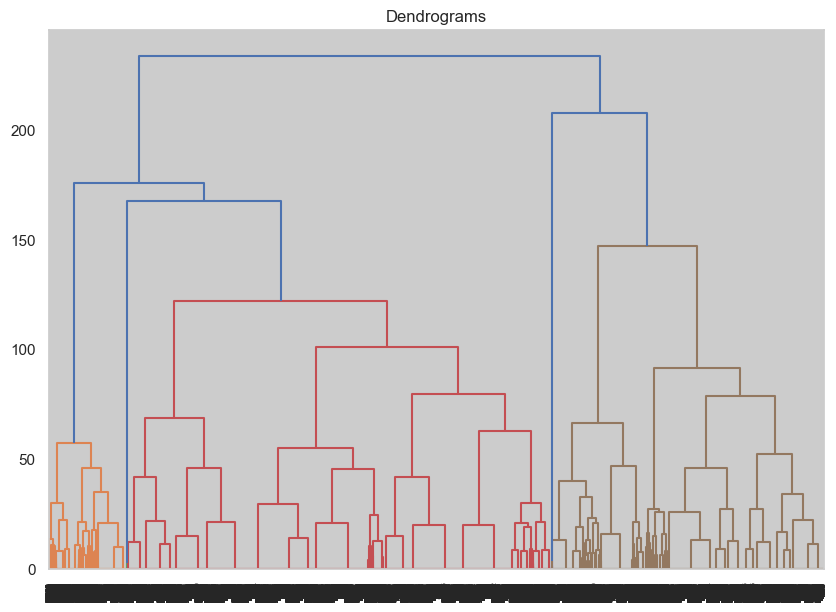

```python
pyplot.figure(figsize=(10, 7))
pyplot.title("Dendrograms")

sample_df = df.sample(n=30000, random_state=42)

dendogram = shc.dendrogram(shc.linkage(sample_df, method='ward'))
```

##### **Gaussian Mixture Model**

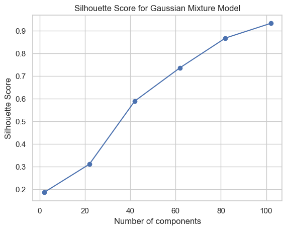

```python
silhouette_scores = []
range_ = range(2, 105, 20)

for k in range_:
    gmm = GaussianMixture(n_components=k)
    gmm.fit(df)
    labels = gmm.predict(df)
    score = silhouette_score(df, labels)
    silhouette_scores.append(score)

plt.plot(range_, silhouette_scores, marker='o')
plt.xlabel('Number of components')
plt.ylabel('Silhouette Score')
plt.title('Silhouette Score for Gaussian Mixture Model')
plt.grid(True)
plt.show()
```

#### **Examining Interaction Sequences of Visits**

- I want to dive deeper into the interaction sequences in visits_df to uncover potential insights.

```python
from mlxtend.preprocessing import TransactionEncoder
from mlxtend.frequent_patterns import apriori, association_rules
```

```python
visits_df = pd.read_csv("./data/visits.csv")
visits_df.head()
```

|  | visit_id | customer_id | start_timestamp | end_timestamp | visit_type | transaction_id |
| --- | --- | --- | --- | --- | --- | --- |
| 0 | 7f94232d-9cca-4893-aebe-9a267a752f87 | de5323eb-5e01-481f-b73a-bb78af953894 | 2023-04-18 10:51:24.477465 | 2023-04-18 11:46:26.893492 | car configuration | NaN |
| 1 | dcb32330-15b0-4fd1-b376-9b9335fee7f9 | 15dcef30-b549-447b-8809-229c9de8526b | 2021-03-03 17:54:25.117599 | 2021-03-03 18:07:25.117599 | viewing | NaN |
| 2 | 8b02d675-1365-45bc-af64-61ef9e79149c | 3b656455-1690-47d9-b7ad-9e0aaa3bb229 | 2023-07-07 13:09:00.000000 | 2023-07-07 13:19:00.000000 | purchasing | d1bfe5f5-edc1-4148-8eb0-8127dd3b52c1 |
| 3 | bdfc7048-adc5-4da7-a37a-4f9d90cf6436 | c583c671-2f8a-47f3-9460-bd444b1811c8 | 2023-09-14 11:25:12.820271 | 2023-09-14 12:20:15.523626 | car configuration | NaN |
| 4 | 2ad3a1e1-0b9c-417f-95f7-70607b0fe96e | da8268d8-4e81-4538-bf1d-836ac4d5b155 | 2020-12-04 19:15:41.833927 | 2020-12-04 19:27:41.833927 | car configuration | NaN |

```python
# Convert timestamp data type to datetime obj
visits_df[["start_timestamp","end_timestamp"]] = visits_df[["start_timestamp","end_timestamp"]].apply(lambda x:pd.to_datetime(x))
visits_df.dtypes
```

```
visit_id                   object
customer_id                object
start_timestamp    datetime64[ns]
end_timestamp      datetime64[ns]
visit_type                 object
transaction_id             object
dtype: object
```

```python
# Construct interaction sequences
visits_df['interaction_sequence'] = visits_df.groupby('customer_id')['visit_type'].transform(lambda x: ','.join(x))
sequences = visits_df.drop_duplicates('customer_id')[['customer_id', 'interaction_sequence']]
sequences
```

|  | customer_id | interaction_sequence |
| --- | --- | --- |
| 0 | de5323eb-5e01-481f-b73a-bb78af953894 | car configuration,testing |
| 1 | 15dcef30-b549-447b-8809-229c9de8526b | viewing,purchasing,viewing,viewing |
| 2 | 3b656455-1690-47d9-b7ad-9e0aaa3bb229 | purchasing,viewing,viewing,testing |
| 3 | c583c671-2f8a-47f3-9460-bd444b1811c8 | car configuration |
| 4 | da8268d8-4e81-4538-bf1d-836ac4d5b155 | car configuration,viewing,purchasing,viewing,c... |
| ... | ... | ... |
| 438555 | 251362d0-c85b-4330-a40f-c43be71a2af8 | viewing |
| 438563 | 4d3635ff-7d79-4d10-9764-88475e80cf23 | car configuration |
| 438565 | 8506eece-e933-4211-b86c-5d52ed1d0def | car configuration |
| 438568 | 9ef1e43b-646d-4605-8a85-d2183e73ff14 | car configuration |
| 438583 | a3b37cb9-a3fa-49fd-841c-7cd647abed1c | car configuration |

136176 rows × 2 columns

```python
# Frequent pattern mining
transactions = sequences['interaction_sequence'].str.split(',')
te = TransactionEncoder()
te_ary = te.fit(transactions).transform(transactions)
df_trans = pd.DataFrame(te_ary, columns=te.columns_)
```

- Adjusting min_support and min_threshold can lead to different discoveries and will be discussed in the presentation

```python
frequent_itemsets = apriori(df_trans, min_support=0.1, use_colnames=True)
rules = association_rules(frequent_itemsets, metric="confidence", min_threshold=0.)
rules
```

|  | antecedents | consequents | antecedent support | consequent support | support | confidence | lift | leverage | conviction | zhangs_metric |
| --- | --- | --- | --- | --- | --- | --- | --- | --- | --- | --- |
| 0 | (purchasing) | (car configuration) | 0.549098 | 0.395995 | 0.213797 | 0.389360 | 0.983245 | -0.003643 | 0.989134 | -0.036416 |
| 1 | (car configuration) | (purchasing) | 0.395995 | 0.549098 | 0.213797 | 0.539898 | 0.983245 | -0.003643 | 0.980004 | -0.027439 |
| 2 | (viewing) | (car configuration) | 0.781937 | 0.395995 | 0.270826 | 0.346353 | 0.874640 | -0.038817 | 0.924054 | -0.396600 |
| 3 | (car configuration) | (viewing) | 0.395995 | 0.781937 | 0.270826 | 0.683913 | 0.874640 | -0.038817 | 0.689884 | -0.191786 |
| 4 | (testing) | (purchasing) | 0.252240 | 0.549098 | 0.173055 | 0.686075 | 1.249458 | 0.034551 | 1.436337 | 0.267001 |
| 5 | (purchasing) | (testing) | 0.549098 | 0.252240 | 0.173055 | 0.315163 | 1.249458 | 0.034551 | 1.091881 | 0.442786 |
| 6 | (purchasing) | (viewing) | 0.549098 | 0.781937 | 0.480694 | 0.875425 | 1.119560 | 0.051334 | 1.750453 | 0.236840 |
| 7 | (viewing) | (purchasing) | 0.781937 | 0.549098 | 0.480694 | 0.614748 | 1.119560 | 0.051334 | 1.170408 | 0.489727 |
| 8 | (testing) | (viewing) | 0.252240 | 0.781937 | 0.168884 | 0.669539 | 0.856258 | -0.028351 | 0.659877 | -0.183341 |
| 9 | (viewing) | (testing) | 0.781937 | 0.252240 | 0.168884 | 0.215982 | 0.856258 | -0.028351 | 0.953754 | -0.434976 |
| 10 | (purchasing, viewing) | (car configuration) | 0.480694 | 0.395995 | 0.190805 | 0.396935 | 1.002375 | 0.000452 | 1.001560 | 0.004563 |
| 11 | (purchasing, car configuration) | (viewing) | 0.213797 | 0.781937 | 0.190805 | 0.892457 | 1.141342 | 0.023629 | 2.027690 | 0.157515 |
| 12 | (viewing, car configuration) | (purchasing) | 0.270826 | 0.549098 | 0.190805 | 0.704528 | 1.283064 | 0.042094 | 1.526040 | 0.302556 |
| 13 | (purchasing) | (viewing, car configuration) | 0.549098 | 0.270826 | 0.190805 | 0.347487 | 1.283064 | 0.042094 | 1.117486 | 0.489277 |
| 14 | (viewing) | (purchasing, car configuration) | 0.781937 | 0.213797 | 0.190805 | 0.244015 | 1.141342 | 0.023629 | 1.039972 | 0.567902 |
| 15 | (car configuration) | (purchasing, viewing) | 0.395995 | 0.480694 | 0.190805 | 0.481836 | 1.002375 | 0.000452 | 1.002204 | 0.003923 |
| 16 | (testing, purchasing) | (viewing) | 0.173055 | 0.781937 | 0.146296 | 0.845370 | 1.081124 | 0.010978 | 1.410231 | 0.090740 |
| 17 | (testing, viewing) | (purchasing) | 0.168884 | 0.549098 | 0.146296 | 0.866249 | 1.577585 | 0.053562 | 3.371209 | 0.440516 |
| 18 | (purchasing, viewing) | (testing) | 0.480694 | 0.252240 | 0.146296 | 0.304343 | 1.206563 | 0.025046 | 1.074898 | 0.329670 |
| 19 | (testing) | (purchasing, viewing) | 0.252240 | 0.480694 | 0.146296 | 0.579988 | 1.206563 | 0.025046 | 1.236407 | 0.228950 |
| 20 | (purchasing) | (testing, viewing) | 0.549098 | 0.168884 | 0.146296 | 0.266430 | 1.577585 | 0.053562 | 1.132973 | 0.811972 |
| 21 | (viewing) | (testing, purchasing) | 0.781937 | 0.173055 | 0.146296 | 0.187094 | 1.081124 | 0.010978 | 1.017270 | 0.344105 |